# dynarules 0.2.0 — visualisation review

917 events → **200 transactions**, **170 co-occurrence rules**, **30 sequential rules**.

> Network views are drawn by **cograph** (`splot()`), not by dynarules. The other five views are ggplot2.

# Co-occurrence rules

## 1. scatter — the default

Support against confidence, coloured by lift. Diverging palette centred on lift = 1, so blue beats independence and red falls short of it.

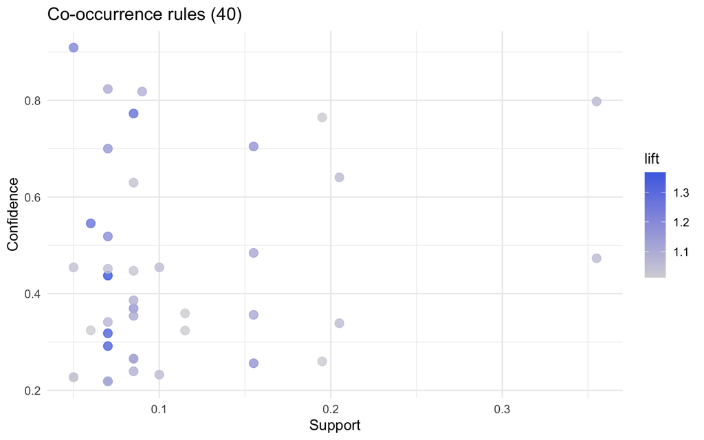

## 2. two-key

The same scatter, coloured by rule order instead. Shows how the longer rules concentrate at low support.

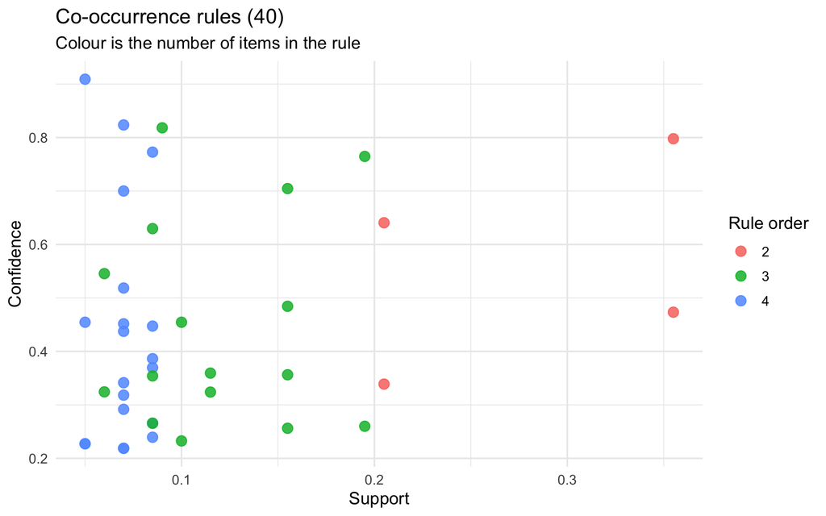

## 3. matrix

Antecedent against consequent, tiled by the chosen measure.

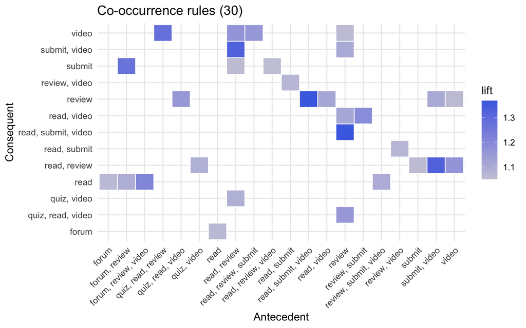

## 4. grouped

Antecedents collapsed to their lead item; point size is support. (arulesViz clusters antecedents here — this groups them deterministically instead, so no clustering dependency is needed.)

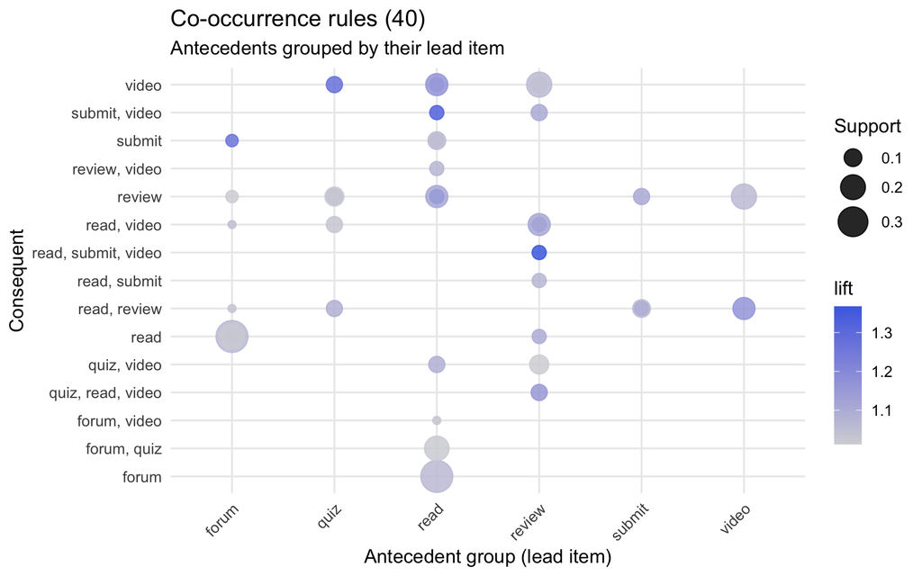

## 5. graph

Handed to `cograph::splot()`. `as_network()` already emits a `cograph_network`, so dynarules does not draw networks itself — it passes the object to the house renderer. Anything `splot()` accepts (layout, node and edge styling) passes straight through the `...`.

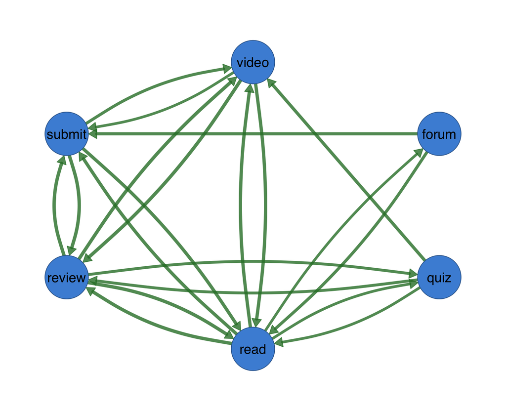

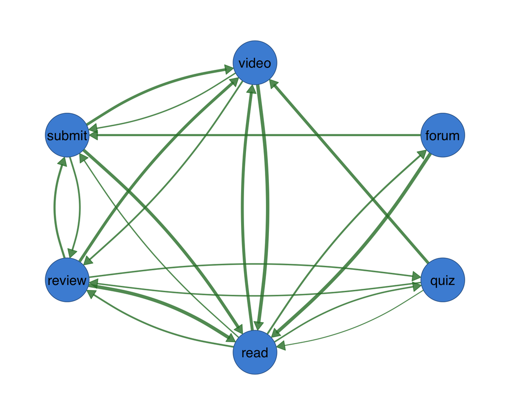

## 6. paracoord

Each rule is a path across item positions; the last position is the consequent.

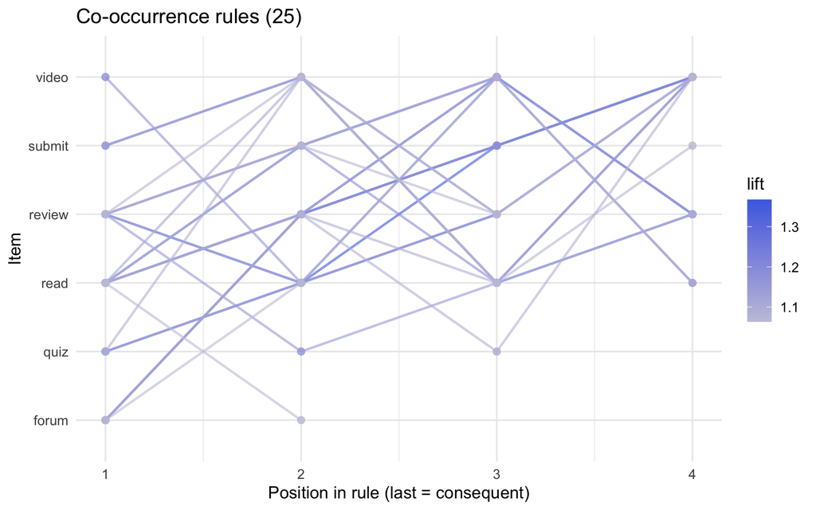

# Sequential rules

The same views over order-aware rules. Note the axis labels switch to the `->` separator and the title reports “Sequential”.

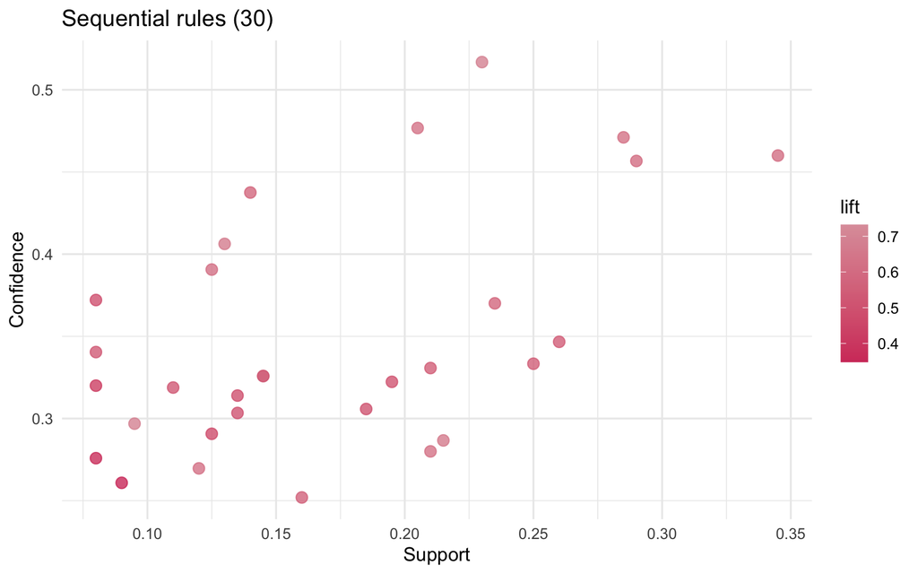

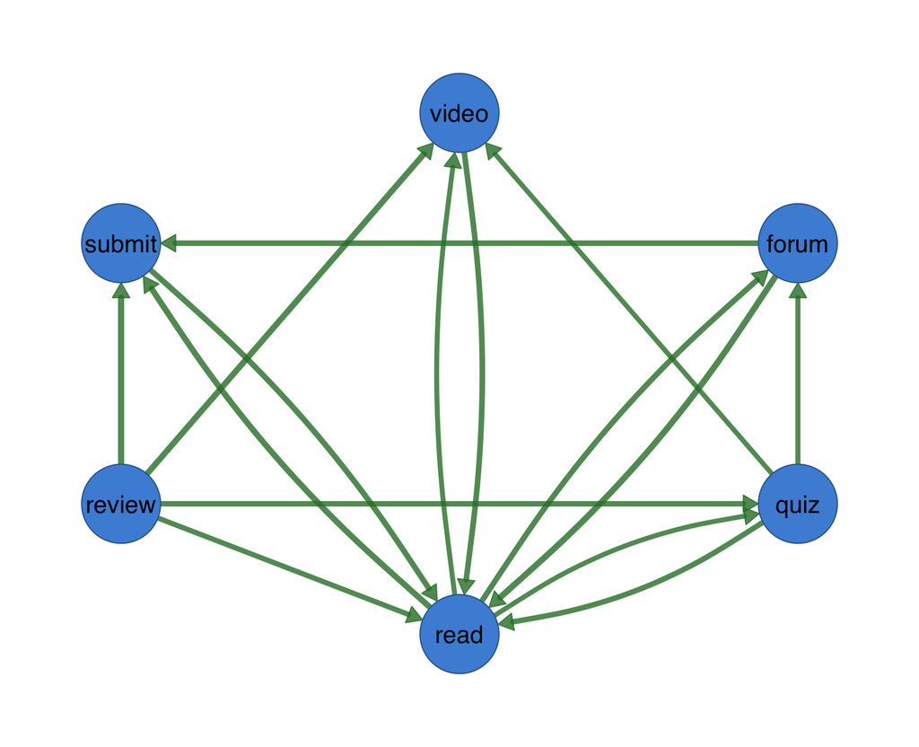

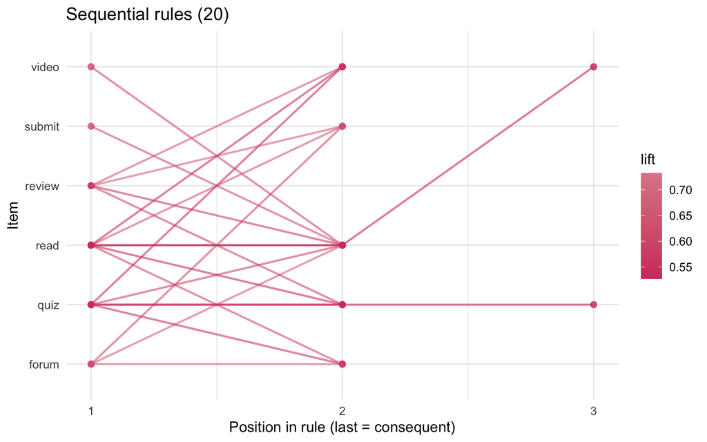

# Colouring by any of the 50 measures

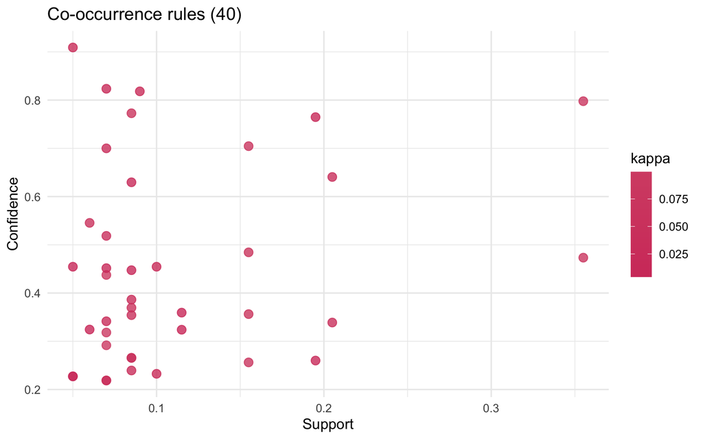

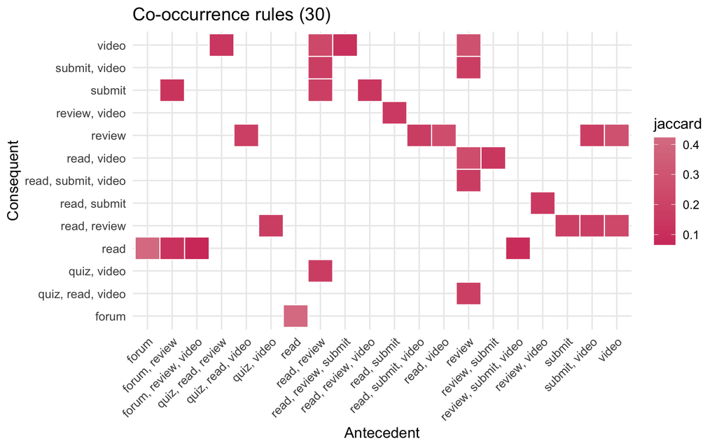